# Deep Learning Lab Session

# First Lab Session - 3 Hours

# Artificial Neural Networks for Handwritten Digits Recognition

Student 1:</b> Romain Rey  
Student 2:</b> Hugo Labaisse

The aim of this session is to practice with Artificial Neural Networks. Answers and experiments should be made by groups of one or two students. Each group should fill and run appropriate notebook cells.

To generate your final report, use print as PDF (Ctrl+P). Do not forget to run all your cells before generating your final report and do not forget to include the names of all participants in the group. The lab session should be completed by April 7th 2017.

# Introduction

In this session, your will implement, train and test a Neural Network for the Handwritten Digits Recognition problem [[1]](http://yann.lecun.com/exdb/mnist/) with different settings of hyper parameters. You will use the MNIST dataset which was constructed from a number of scanned document dataset available from the National Institute of Standards and Technology (NIST). Images of digits were taken from a variety of scanned documents, normalized in size and centered.

This assignment includes a written part of programms to help you understand how to build and train your neural net and then to test your code and get restults.

1. NeuralNetwork.py
2. transfer_functions.py
3. utils.py

Functions defined inside the python files mentionned above can be imported using the python command : from filename import *

You will use the following libraries:

1. [numpy](http://cs231n.github.io/python-numpy-tutorial/) : for creating arrays and using methods to manipulate arrays.
2. [matplotlib](http://matplotlib.org/) : for making plots

# Section 1 : My First Neural Network

**Part 1**: Before designing and writing your code, you will first work on a neural network by hand. Consider the above Neural network with two inputs $X=(x1,x2)$, one hidden layers and a single output unit $(y)$. The initial weights are set to random values. Neurons 6 and 7 represent the bias. Bias values are equal to 1.  
Training sample, X = (0.8, 0.2), whose class label is Y=0.4.

Assume that the neurons have a Sigmoid activation function $f(x)=\frac{1}{(1+e^{-x})}$ and the learning rate $\mu$=1

**Question 1.1.1**: Compute the new values of weights $w_{i,j}$ after a forward pass and a backward pass. $w_{i,j}$ is the weight of the connexion between neuron $i$ and neuron $j$.

```python
# transfer functions


import numpy as np

def sigmoid(x):
    return 1 / (1 + np.exp(-x))
# derivative of sigmoid

def dsigmoid(y):
    return y * (1.0 - y)

x1 = 0.6

calc = sigmoid(-0.6*sigmoid(x1)+0.4*sigmoid(-0.76)+0.5)
diff = calc-0.4
w35 = -0.6-(diff*dsigmoid(calc)*sigmoid(x1))
w45 = 0.4-(diff*dsigmoid(calc)*sigmoid(-0.76))
w75 = 0.5-(diff*dsigmoid(calc))


dedu1 = diff*dsigmoid(calc)


#print('0.6   '+str(sigmoid(x1)))
#print('-0.76    '+str(sigmoid(-0.76)))
#print('calc    '+str(sigmoid(-0.6*sigmoid(x1)+0.4*sigmoid(-0.76)+0.5)))

print('w35    '+str(-0.6-(diff*dsigmoid(calc)*sigmoid(x1))))
print('w45    '+str(0.4-(diff*dsigmoid(calc)*sigmoid(-0.76))))
print('w75    '+str(0.5-(diff*dsigmoid(calc))))

print('w13    '+str(0.3-(dedu1*(w35+w45+w75)*dsigmoid(x1)*0.8)))
print('w14    '+str(-0.5-(dedu1*(w35+w45+w75)*dsigmoid(sigmoid(-0.76))*0.8)))

print('w23    '+str(0.8-(dedu1*(w35+w45+w75)*dsigmoid(x1)*0.2)))
print('w24    '+str(0.2-(dedu1*(w35+w45+w75)*dsigmoid(-0.76)*0.2)))

print('w63    '+str(0.2-(dedu1*(w35+w45+w75)*dsigmoid(x1)*1)))
print('w64    '+str(-0.4-(dedu1*(w35+w45+w75)*dsigmoid(-0.76)*1)))
```

```
w35    -0.625414675063
w45    0.387457272178
w75    0.460637455535
w13    0.298317071333
w14    -0.501522425118
w23    0.799579267833
w24    0.202344880609
w63    0.197896339166
w64    -0.388275596953
```

**Part 2**: Neural Network Implementation

Please read all source files carefully and understand the data structures and all functions. You are to complete the missing code. First you should define the neural network (using the NeuralNetwork class, see in the NeuralNetwork.py file) and reinitialise weights. Then you will to complete the Feed Forward and the Back-propagation functions.

**Question 1.2.1**: Define the neural network corresponding to the one in part 1

```python
from NeuralNetwork import *
#create the network
my_first_net = NeuralNetwork(2,2,1,learning_rate= 1.0)
```

```python
#Data preparation
X=[0.8,0.2]
Y=[0.4]
data=[]
data.append(X)
data.append(Y)

#initialize weights
wi=np.array([[0.3,-0.5],[0.8,0.2],[0.2,-0.4]])
wo=np.array([[-0.6],[0.4],[0.5]])
my_first_net.weights_initialisation(wi,wo)
print(my_first_net.W_input_to_hidden)
print(my_first_net.W_hidden_to_output)
```

```
[[ 0.3 -0.5]
 [ 0.8  0.2]
 [ 0.2 -0.4]]
[[-0.6]
 [ 0.4]
 [ 0.5]]
```

**Question 1.2.2**: Implement the Feed Forward function (feedForward(X) in the NeuralNetwork.py file)

```python
# Implement it in the NeuralNetwork.py file and when finalised copy and paste your FeedForward function here

def feedForward(self, inputs):
       # Compute input activations
        self.a_input = inputs+[1]

        #Compute  hidden activations
        for i in range(self.hidden-1):
            s=0
            for j in range(self.input):
                s += self.a_input[j]*self.W_input_to_hidden[j][i]
            o = sigmoid(s)
            self.a_hidden[i] = o
        self.a_hidden[-1] = 1

        # Compute output activations
        for i in range(self.output):
                s=0
                for j in range(self.hidden):
                    s += self.a_hidden[j]*self.W_hidden_to_output[j][i]
                o = sigmoid(s)
                self.a_out[i] = o
        return self.a_out
```

Check your network outputs the expected value (the one you computed in question 1.1)

```python
#test my  Feed Forward function
Output_activation=my_first_net.feedForward(X)
print("output activation =%.3f" %(Output_activation))
```

```
output activation =0.560
```

**Question 1.2.3**: Implement the Back-propagation Algorithm (backPropagate(Y) in the NeuralNetwork.py file)

```python
 def backPropagate(self, targets):


         # calculate error terms for output
        # for i in range(len(self.a_out)):
        #    E+=(1/2)*(self.a-out[i]-targets[i])**2

        uVect=[]
        for i in range(self.output):
            u=0
            for j in range(self.hidden):
                        u += self.a_hidden[j]*self.W_hidden_to_output[j][i]
            uVect.append(u)

        dEdw=[]
        for i in range(len(self.a_hidden)):
            dEdwi = []
            for j in range(len(self.a_out)):
                dEdwi.append((self.a_out[j]
                              -targets[j])
                             *dsigmoid(sigmoid(uVect[j]))
                             *self.a_hidden[i])
            dEdw.append(dEdwi)

        # update output weights

        for i in range(len(self.a_hidden)):
            for j in range(len(self.a_out)):
                self.W_hidden_to_output[i][j] -= self.learning_rate*dEdw[i][j]


        # calculate error terms for hidden
        dEdw_hidd = []
        for i in range(len(self.a_input)):
            dEdw_hiddi=[]
            s=0
            for k in range(len(self.a_hidden)):

                for j in range(len(self.a_out)):
                    s= s + ((self.a_out[j]-targets[j])*dsigmoid(sigmoid(uVect[j])))*self.W_hidden_to_output[k][j]
                    a= (self.a_out[j]-targets[j])*dsigmoid(sigmoid(uVect[j]))
                    b=self.W_hidden_to_output[k][j]
                dEdw_hiddi.append(s*(dsigmoid(self.a_hidden[k]))*self.a_input[i])

            dEdw_hidd.append(dEdw_hiddi)
```

Check the gradient values and weight updates are correct (similar to the ones you computed in question 1.1)

```python
#test my  Back-propagation function
my_first_net.backPropagate(Y)
#Print weights after backpropagation
print('wi_new=', my_first_net.W_input_to_hidden)
print('wo_new=', my_first_net.W_hidden_to_output)
```

```
wi_new= [[ 0.29549425 -0.50162687]
 [ 0.79887356  0.19959328]
 [ 0.19436781 -0.40203359]]
wo_new= [[-0.62541468]
 [ 0.38745727]
 [ 0.46063746]]
```

# Section 2 : The MNIST Challenge!

**Data Preparation**

The MNIST dataset consists of handwritten digit images it contains 60,000 examples for the training set and 10,000 examples for testing. In this Lab Session, the official training set of 60,000 is divided into an actual training set of 50,000 examples, 10,000 validation examples and 10,000 examples for test. All digit images have been size-normalized and centered in a fixed size image of 28 x 28 pixels. The images are stored in byte form you will use the NumPy python library to read the data files into NumPy arrays that we will use to train the ANN.

The MNIST dataset is available in the Data folder. To get the training, testing and validation data, run the the load_data() function.

```python
from utils import *
training_data, validation_data, test_data=load_data()
```

```
Loading MNIST data .....
Done.
```

**MNIST Dataset Digits Visualisation**

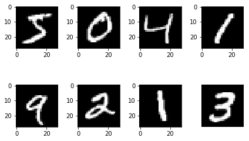

```python
ROW = 2
COLUMN = 4
for i in range(ROW * COLUMN):
    # train[i][0] is i-th image data with size 28x28
    image = training_data[i][0].reshape(28, 28)
    plt.subplot(ROW, COLUMN, i+1)
    plt.imshow(image, cmap='gray')  # cmap='gray' is for black and white picture.
plt.axis('off')  # do not show axis value
plt.tight_layout()   # automatic padding between subplots
plt.show()
```

**Part 1**: Creating the Neural Networks

The input layer of the neural network contains neurons encoding the values of the input pixels. The training data for the network will consist of many 28 by 28 pixel images of scanned handwritten digits, and so the input layer contains 784=28×28 neurons. The second layer of the network is a hidden layer, we set the neuron number in the hidden layer to 30. The output layer contains 10 neurons.

**Question 2.1.1**: Create the network described above using the NeuralNetwork class

```python
#create the network
from NeuralNetwork import *
my_mnist_net = NeuralNetwork(784,30,10,50,0.1)
```

**Question 2.1.2**: Add the information about the performance of the neural network on the test set at each epoch

```python
test_accuracy=my_mnist_net.predict(test_data, 'sigmoid')/100
print('Test_Accuracy  %-2.2f' % test_accuracy)
```

```
Test_Accuracy  8.22
```

**Question 2.1.3**: Train the Neural Network and comment your findings

```python
#train your network
stats_01 = my_mnist_net.train(training_data,validation_data, 'sigmoid')

#save your model in Models/ using a distinguishing name for your model (architecture, learning rate, etc...)
my_mnist_net.save("Models/net_h30_lr01.pkl")
```

```
Iteration:  1/50[==============] -Error: 0.0071068926  -Training_Accuracy:  90.99  -time: 19.74
Iteration:  2/50[==============] -Error: 0.0059017321  -Training_Accuracy:  92.22  -time: 37.00
Iteration:  3/50[==============] -Error: 0.0052437168  -Training_Accuracy:  92.97  -time: 54.06
Iteration:  4/50[==============] -Error: 0.0047979190  -Training_Accuracy:  93.37  -time: 71.29
Iteration:  5/50[==============] -Error: 0.0044820447  -Training_Accuracy:  93.88  -time: 88.41
Iteration:  6/50[==============] -Error: 0.0042324111  -Training_Accuracy:  94.06  -time: 105.46
Iteration:  7/50[==============] -Error: 0.0040251036  -Training_Accuracy:  94.41  -time: 126.19
Iteration:  8/50[==============] -Error: 0.0038585075  -Training_Accuracy:  94.69  -time: 144.10
Iteration:  9/50[==============] -Error: 0.0036908620  -Training_Accuracy:  94.90  -time: 163.48
Iteration: 10/50[==============] -Error: 0.0035500517  -Training_Accuracy:  94.90  -time: 181.34
Iteration: 11/50[==============] -Error: 0.0034475438  -Training_Accuracy:  95.19  -time: 200.62
Iteration: 12/50[==============] -Error: 0.0033382140  -Training_Accuracy:  95.43  -time: 226.02
Iteration: 13/50[==============] -Error: 0.0032488348  -Training_Accuracy:  95.57  -time: 246.45
Iteration: 14/50[==============] -Error: 0.0031642141  -Training_Accuracy:  95.65  -time: 269.91
Iteration: 15/50[==============] -Error: 0.0030808217  -Training_Accuracy:  95.79  -time: 292.36
Iteration: 16/50[==============] -Error: 0.0030168944  -Training_Accuracy:  95.85  -time: 311.72
Iteration: 17/50[==============] -Error: 0.0029481545  -Training_Accuracy:  95.93  -time: 338.86
Iteration: 18/50[==============] -Error: 0.0028880480  -Training_Accuracy:  95.95  -time: 362.84
Iteration: 19/50[==============] -Error: 0.0028093930  -Training_Accuracy:  96.04  -time: 386.52
Iteration: 20/50[==============] -Error: 0.0027658216  -Training_Accuracy:  96.16  -time: 404.98
Iteration: 21/50[==============] -Error: 0.0027244721  -Training_Accuracy:  96.16  -time: 423.08
Iteration: 22/50[==============] -Error: 0.0026835488  -Training_Accuracy:  96.24  -time: 443.58
Iteration: 23/50[==============] -Error: 0.0026286718  -Training_Accuracy:  96.31  -time: 465.27
Iteration: 24/50[==============] -Error: 0.0025863020  -Training_Accuracy:  96.38  -time: 486.91
Iteration: 25/50[==============] -Error: 0.0025477019  -Training_Accuracy:  96.39  -time: 510.47
Iteration: 26/50[==============] -Error: 0.0025158598  -Training_Accuracy:  96.46  -time: 531.99
Iteration: 27/50[==============] -Error: 0.0024834779  -Training_Accuracy:  96.50  -time: 553.41
Iteration: 28/50[==============] -Error: 0.0024463742  -Training_Accuracy:  96.60  -time: 575.12
Iteration: 29/50[==============] -Error: 0.0024103728  -Training_Accuracy:  96.47  -time: 596.47
Iteration: 30/50[==============] -Error: 0.0023897830  -Training_Accuracy:  96.64  -time: 618.17
Iteration: 31/50[==============] -Error: 0.0023560799  -Training_Accuracy:  96.67  -time: 639.82
Iteration: 32/50[==============] -Error: 0.0023314890  -Training_Accuracy:  96.75  -time: 661.25
Iteration: 33/50[==============] -Error: 0.0023030272  -Training_Accuracy:  96.78  -time: 685.00
Iteration: 34/50[==============] -Error: 0.0022769054  -Training_Accuracy:  96.77  -time: 705.46
Iteration: 35/50[==============] -Error: 0.0022441688  -Training_Accuracy:  96.82  -time: 729.98
Iteration: 36/50[==============] -Error: 0.0022259214  -Training_Accuracy:  96.88  -time: 754.13
Iteration: 37/50[==============] -Error: 0.0022044867  -Training_Accuracy:  96.93  -time: 775.78
Iteration: 38/50[==============] -Error: 0.0021819416  -Training_Accuracy:  96.89  -time: 794.74
Iteration: 39/50[==============] -Error: 0.0021667671  -Training_Accuracy:  96.96  -time: 819.91
Iteration: 40/50[==============] -Error: 0.0021424220  -Training_Accuracy:  96.96  -time: 842.44
Iteration: 41/50[==============] -Error: 0.0021180718  -Training_Accuracy:  96.93  -time: 866.68
Iteration: 42/50[==============] -Error: 0.0021055963  -Training_Accuracy:  97.02  -time: 887.68
Iteration: 43/50[==============] -Error: 0.0020869801  -Training_Accuracy:  97.04  -time: 908.39
Iteration: 44/50[==============] -Error: 0.0020632844  -Training_Accuracy:  97.08  -time: 926.29
Iteration: 45/50[==============] -Error: 0.0020516217  -Training_Accuracy:  97.09  -time: 949.22
Iteration: 46/50[==============] -Error: 0.0020417117  -Training_Accuracy:  97.04  -time: 973.53
Iteration: 47/50[==============] -Error: 0.0020226519  -Training_Accuracy:  97.13  -time: 995.71
Iteration: 48/50[==============] -Error: 0.0020118411  -Training_Accuracy:  97.15  -time: 1017.19
Iteration: 49/50[==============] -Error: 0.0019934388  -Training_Accuracy:  97.17  -time: 1038.20
Iteration: 50/50[==============] -Error: 0.0019768396  -Training_Accuracy:  97.18  -time: 1064.97
```

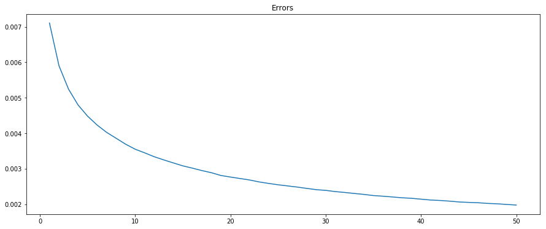

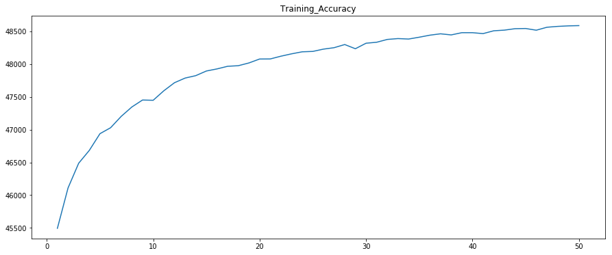

```
Max training accuracy = 48588
Min error = 0.0020
```

```python
plt.figure(figsize=(15,6))
plt.plot(range(1,50+1),stats_01[0])
plt.title('Errors')
plt.show()
plt.figure(figsize=(15,6))
plt.plot(range(1,50+1), stats_01[1])
plt.title('Training_Accuracy')
plt.show()
print "Max training accuracy =", int(np.amax(stats_01[1]))
print ("Min error = %.4f" %(np.amin(stats_01[0])))
```

The accuracy increases and the error decreases with more iteration. At each iteration, the neural network improves through back propagation (modifies the weight).,The curve looks good (like exponential) so we have a good learning rate.

**Question 2.1.4**: Guess digit, Implement and test a python function that predict the class of a digit (the folder images_test contains some examples of images of digits)

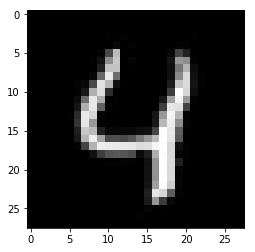

```
The digit is 4
```

```python
#Your implementation goes here
from PIL import Image
import numpy as np

img = Image.open('Images_test/4.bmp').convert('L').resize((28,28))
img = 255 - np.array(img)
plt.imshow(img,cmap='gray')
plt.show()

input_image = np.reshape(img, (784,))
guess = my_mnist_net.guess(input_image)
print "The digit is", guess
```

**Part 2**: Change the neural network structure and parameters to optimize performance

**Question 2.2.1**: Change the learning rate (0.001, 0.1, 1.0 , 10). Train the new neural nets with the original specifications (Part 2.1), for 50 iterations. Plot test accuracy vs iteration for each learning rate on the same graph. Report the maximum test accuracy achieved for each learning rate. Which one achieves the maximum test accuracy?

```python
#Your implementation with a learning rate of 0.001 goes here
my_mnist_net = NeuralNetwork(784,30,10,50,0.001)
stats_001 = my_mnist_net.train(training_data,validation_data, 'sigmoid')
my_mnist_net.save("Models/net_h30_lr001.pkl")
```

```
Iteration:  1/50[==============] -Error: 0.0488033767  -Training_Accuracy:  37.58  -time: 23.77
Iteration:  2/50[==============] -Error: 0.0397988284  -Training_Accuracy:  46.60  -time: 53.63
Iteration:  3/50[==============] -Error: 0.0367813807  -Training_Accuracy:  52.76  -time: 74.83
Iteration:  4/50[==============] -Error: 0.0343343083  -Training_Accuracy:  57.02  -time: 96.76
Iteration:  5/50[==============] -Error: 0.0322860146  -Training_Accuracy:  59.87  -time: 118.06
Iteration:  6/50[==============] -Error: 0.0305323269  -Training_Accuracy:  62.42  -time: 138.64
Iteration:  7/50[==============] -Error: 0.0290111282  -Training_Accuracy:  64.34  -time: 161.81
Iteration:  8/50[==============] -Error: 0.0276851206  -Training_Accuracy:  66.07  -time: 181.45
Iteration:  9/50[==============] -Error: 0.0265297549  -Training_Accuracy:  67.56  -time: 199.56
Iteration: 10/50[==============] -Error: 0.0255146424  -Training_Accuracy:  68.97  -time: 217.31
Iteration: 11/50[==============] -Error: 0.0246146724  -Training_Accuracy:  70.00  -time: 235.64
Iteration: 12/50[==============] -Error: 0.0238121747  -Training_Accuracy:  71.10  -time: 253.69
Iteration: 13/50[==============] -Error: 0.0230885661  -Training_Accuracy:  72.08  -time: 271.07
Iteration: 14/50[==============] -Error: 0.0224318737  -Training_Accuracy:  72.88  -time: 288.23
Iteration: 15/50[==============] -Error: 0.0218326312  -Training_Accuracy:  73.77  -time: 305.71
Iteration: 16/50[==============] -Error: 0.0212785195  -Training_Accuracy:  74.46  -time: 323.22
Iteration: 17/50[==============] -Error: 0.0207677835  -Training_Accuracy:  75.09  -time: 340.51
Iteration: 18/50[==============] -Error: 0.0202898037  -Training_Accuracy:  75.93  -time: 362.00
Iteration: 19/50[==============] -Error: 0.0198471843  -Training_Accuracy:  76.39  -time: 380.50
Iteration: 20/50[==============] -Error: 0.0194319915  -Training_Accuracy:  76.87  -time: 397.60
Iteration: 21/50[==============] -Error: 0.0190419559  -Training_Accuracy:  77.39  -time: 416.27
Iteration: 22/50[==============] -Error: 0.0186748944  -Training_Accuracy:  77.89  -time: 435.46
Iteration: 23/50[==============] -Error: 0.0183285268  -Training_Accuracy:  78.37  -time: 453.97
Iteration: 24/50[==============] -Error: 0.0180012531  -Training_Accuracy:  78.83  -time: 471.29
Iteration: 25/50[==============] -Error: 0.0176913933  -Training_Accuracy:  79.15  -time: 488.37
Iteration: 26/50[==============] -Error: 0.0173988914  -Training_Accuracy:  79.54  -time: 505.94
Iteration: 27/50[==============] -Error: 0.0171198309  -Training_Accuracy:  79.89  -time: 523.24
Iteration: 28/50[==============] -Error: 0.0168545705  -Training_Accuracy:  80.27  -time: 540.32
Iteration: 29/50[==============] -Error: 0.0166018034  -Training_Accuracy:  80.54  -time: 558.70
Iteration: 30/50[==============] -Error: 0.0163607351  -Training_Accuracy:  80.84  -time: 577.05
Iteration: 31/50[==============] -Error: 0.0161307988  -Training_Accuracy:  81.19  -time: 594.54
Iteration: 32/50[==============] -Error: 0.0159101894  -Training_Accuracy:  81.40  -time: 612.65
Iteration: 33/50[==============] -Error: 0.0156998688  -Training_Accuracy:  81.69  -time: 629.86
Iteration: 34/50[==============] -Error: 0.0154984799  -Training_Accuracy:  81.89  -time: 647.58
Iteration: 35/50[==============] -Error: 0.0153049671  -Training_Accuracy:  82.13  -time: 665.74
Iteration: 36/50[==============] -Error: 0.0151179007  -Training_Accuracy:  82.38  -time: 682.81
Iteration: 37/50[==============] -Error: 0.0149406017  -Training_Accuracy:  82.58  -time: 701.00
Iteration: 38/50[==============] -Error: 0.0147691062  -Training_Accuracy:  82.76  -time: 719.73
Iteration: 39/50[==============] -Error: 0.0146031405  -Training_Accuracy:  82.95  -time: 737.89
Iteration: 40/50[==============] -Error: 0.0144440423  -Training_Accuracy:  83.16  -time: 755.55
Iteration: 41/50[==============] -Error: 0.0142894091  -Training_Accuracy:  83.29  -time: 773.80
Iteration: 42/50[==============] -Error: 0.0141414746  -Training_Accuracy:  83.49  -time: 793.01
Iteration: 43/50[==============] -Error: 0.0139978346  -Training_Accuracy:  83.65  -time: 811.60
Iteration: 44/50[==============] -Error: 0.0138588583  -Training_Accuracy:  83.78  -time: 829.85
Iteration: 45/50[==============] -Error: 0.0137254203  -Training_Accuracy:  83.97  -time: 848.81
Iteration: 46/50[==============] -Error: 0.0135951259  -Training_Accuracy:  84.08  -time: 866.48
Iteration: 47/50[==============] -Error: 0.0134692418  -Training_Accuracy:  84.22  -time: 884.12
Iteration: 48/50[==============] -Error: 0.0133469884  -Training_Accuracy:  84.39  -time: 901.06
Iteration: 49/50[==============] -Error: 0.0132292018  -Training_Accuracy:  84.50  -time: 918.58
Iteration: 50/50[==============] -Error: 0.0131143147  -Training_Accuracy:  84.60  -time: 935.53
```

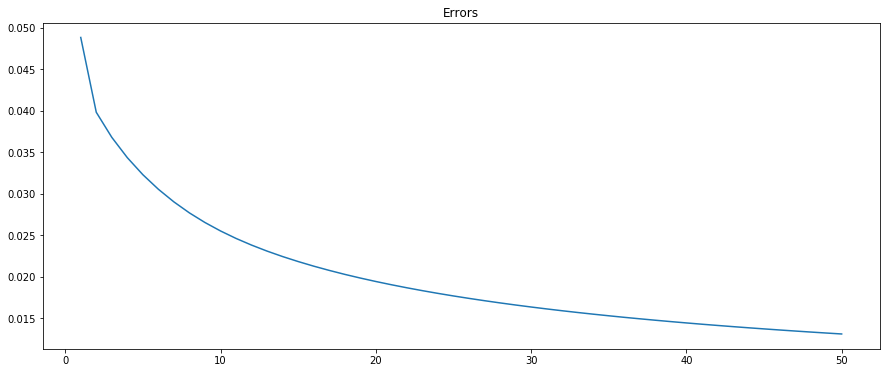

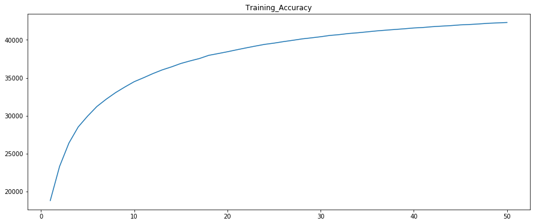

```
Max training accuracy = 42301
Min error = 0.0131
```

```python
plt.figure(figsize=(15,6))
plt.plot(range(1,50+1),stats_001[0])
plt.title('Errors')
plt.show()
plt.figure(figsize=(15,6))
plt.plot(range(1,50+1), stats_001[1])
plt.title('Training_Accuracy')
plt.show()
print "Max training accuracy =", int(np.amax(stats_001[1]))
print ("Min error = %.4f" %(np.amin(stats_001[0])))
```

Here the learning rate is smaller than before. It results in having an error bigger than before and accurcy smaller than before after 50 iterations. It is because with a smaller learning rate, it needs more iterations to have the same result.

```python
#Your implementation with a learning rate of 1.0 goes here
my_mnist_net = NeuralNetwork(784,30,10,50,1.0)
stats_1 = my_mnist_net.train(training_data,validation_data, 'sigmoid')
my_mnist_net.save("Models/net_h30_lr1.pkl")
```

```
Iteration:  1/50[==============] -Error: 0.0055507438  -Training_Accuracy:  90.77  -time: 17.30
Iteration:  2/50[==============] -Error: 0.0040444306  -Training_Accuracy:  92.13  -time: 34.41
Iteration:  3/50[==============] -Error: 0.0037055880  -Training_Accuracy:  93.01  -time: 53.53
Iteration:  4/50[==============] -Error: 0.0035672927  -Training_Accuracy:  93.61  -time: 73.70
Iteration:  5/50[==============] -Error: 0.0033933512  -Training_Accuracy:  93.83  -time: 97.17
Iteration:  6/50[==============] -Error: 0.0032490218  -Training_Accuracy:  94.08  -time: 117.87
Iteration:  7/50[==============] -Error: 0.0032159927  -Training_Accuracy:  94.74  -time: 136.78
Iteration:  8/50[==============] -Error: 0.0030990373  -Training_Accuracy:  94.68  -time: 155.41
Iteration:  9/50[==============] -Error: 0.0030900205  -Training_Accuracy:  94.42  -time: 174.58
Iteration: 10/50[==============] -Error: 0.0029981645  -Training_Accuracy:  94.91  -time: 193.39
Iteration: 11/50[==============] -Error: 0.0030694075  -Training_Accuracy:  95.19  -time: 212.11
Iteration: 12/50[==============] -Error: 0.0029951390  -Training_Accuracy:  95.31  -time: 230.68
Iteration: 13/50[==============] -Error: 0.0028809320  -Training_Accuracy:  94.89  -time: 249.62
Iteration: 14/50[==============] -Error: 0.0029139122  -Training_Accuracy:  95.31  -time: 268.33
Iteration: 15/50[==============] -Error: 0.0028684544  -Training_Accuracy:  95.12  -time: 287.02
Iteration: 16/50[==============] -Error: 0.0028201227  -Training_Accuracy:  95.44  -time: 305.53
Iteration: 17/50[==============] -Error: 0.0028352826  -Training_Accuracy:  94.89  -time: 326.18
Iteration: 18/50[==============] -Error: 0.0028449476  -Training_Accuracy:  95.21  -time: 346.61
Iteration: 19/50[==============] -Error: 0.0027407646  -Training_Accuracy:  95.48  -time: 368.49
Iteration: 20/50[==============] -Error: 0.0028014452  -Training_Accuracy:  95.28  -time: 389.53
Iteration: 21/50[==============] -Error: 0.0026890385  -Training_Accuracy:  95.79  -time: 409.98
Iteration: 22/50[==============] -Error: 0.0027067052  -Training_Accuracy:  95.79  -time: 430.90
Iteration: 23/50[==============] -Error: 0.0026716859  -Training_Accuracy:  95.64  -time: 451.55
Iteration: 24/50[==============] -Error: 0.0027247293  -Training_Accuracy:  95.81  -time: 473.03
Iteration: 25/50[==============] -Error: 0.0026852169  -Training_Accuracy:  95.84  -time: 493.44
Iteration: 26/50[==============] -Error: 0.0026129371  -Training_Accuracy:  96.22  -time: 513.79
Iteration: 27/50[==============] -Error: 0.0026148561  -Training_Accuracy:  95.96  -time: 533.97
Iteration: 28/50[==============] -Error: 0.0025966726  -Training_Accuracy:  96.03  -time: 554.99
Iteration: 29/50[==============] -Error: 0.0024864698  -Training_Accuracy:  96.17  -time: 575.31
Iteration: 30/50[==============] -Error: 0.0025158448  -Training_Accuracy:  96.18  -time: 598.70
Iteration: 31/50[==============] -Error: 0.0024830364  -Training_Accuracy:  96.26  -time: 619.17
Iteration: 32/50[==============] -Error: 0.0025423356  -Training_Accuracy:  96.14  -time: 642.57
Iteration: 33/50[==============] -Error: 0.0025658323  -Training_Accuracy:  96.17  -time: 665.08
Iteration: 34/50[==============] -Error: 0.0025624447  -Training_Accuracy:  96.01  -time: 685.77
Iteration: 35/50[==============] -Error: 0.0025179753  -Training_Accuracy:  95.94  -time: 707.70
Iteration: 36/50[==============] -Error: 0.0025522282  -Training_Accuracy:  96.31  -time: 731.37
Iteration: 37/50[==============] -Error: 0.0024964026  -Training_Accuracy:  96.46  -time: 755.59
Iteration: 38/50[==============] -Error: 0.0024469828  -Training_Accuracy:  96.37  -time: 776.66
Iteration: 39/50[==============] -Error: 0.0024744197  -Training_Accuracy:  96.41  -time: 796.04
Iteration: 40/50[==============] -Error: 0.0024459840  -Training_Accuracy:  96.21  -time: 815.86
Iteration: 41/50[==============] -Error: 0.0024320449  -Training_Accuracy:  96.46  -time: 836.16
Iteration: 42/50[==============] -Error: 0.0023894295  -Training_Accuracy:  96.30  -time: 857.95
Iteration: 43/50[==============] -Error: 0.0023299520  -Training_Accuracy:  96.41  -time: 877.43
Iteration: 44/50[==============] -Error: 0.0023607794  -Training_Accuracy:  96.54  -time: 899.06
Iteration: 45/50[==============] -Error: 0.0023862219  -Training_Accuracy:  96.29  -time: 922.27
Iteration: 46/50[==============] -Error: 0.0024364171  -Training_Accuracy:  96.23  -time: 944.30
Iteration: 47/50[==============] -Error: 0.0022842172  -Training_Accuracy:  96.76  -time: 967.06
Iteration: 48/50[==============] -Error: 0.0023010464  -Training_Accuracy:  96.49  -time: 988.21
Iteration: 49/50[==============] -Error: 0.0023505347  -Training_Accuracy:  96.53  -time: 1008.46
Iteration: 50/50[==============] -Error: 0.0022484802  -Training_Accuracy:  96.58  -time: 1030.42
```

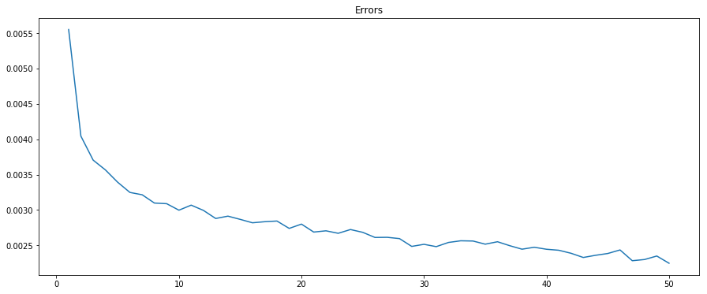

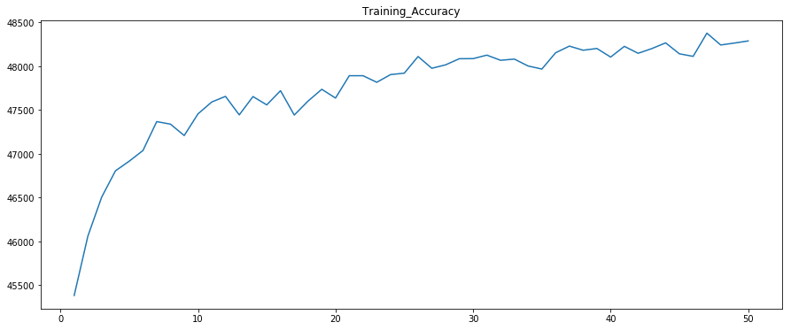

```
Max training accuracy = 48379
Min error = 0.0022
```

```python
plt.figure(figsize=(15,6))
plt.plot(range(1,50+1),stats_1[0])
plt.title('Errors')
plt.show()
plt.figure(figsize=(15,6))
plt.plot(range(1,50+1), stats_1[1])
plt.title('Training_Accuracy')
plt.show()
print "Max training accuracy =", int(np.amax(stats_1[1]))
print ("Min error = %.4f" %(np.amin(stats_1[0])))
```

```python
#Your implementation with a learning rate of 10 goes here
my_mnist_net = NeuralNetwork(784,30,10,50,10)
stats_10 = my_mnist_net.train(training_data,validation_data, 'sigmoid')
my_mnist_net.save("Models/net_h30_l10.pkl")
```

```
Iteration:  1/50[==============] -Error: 0.0495468528  -Training_Accuracy:  10.93  -time: 21.67
Iteration:  2/50[==============] -Error: 0.0498263446  -Training_Accuracy:  10.44  -time: 43.58
Iteration:  3/50[==============] -Error: 0.0499817581  -Training_Accuracy:  9.90  -time: 65.46
Iteration:  4/50[==============] -Error: 0.0500135759  -Training_Accuracy:  9.84  -time: 88.26
Iteration:  5/50[==============] -Error: 0.0493952577  -Training_Accuracy:  12.34  -time: 108.78
Iteration:  6/50[==============] -Error: 0.0478374432  -Training_Accuracy:  14.79  -time: 128.40
Iteration:  7/50[==============] -Error: 0.0535710527  -Training_Accuracy:  18.35  -time: 147.84
Iteration:  8/50[==============] -Error: 0.0469868041  -Training_Accuracy:  20.96  -time: 167.53
Iteration:  9/50[==============] -Error: 0.0475442822  -Training_Accuracy:  19.72  -time: 186.96
Iteration: 10/50[==============] -Error: 0.0468641473  -Training_Accuracy:  19.57  -time: 206.69
Iteration: 11/50[==============] -Error: 0.0479894039  -Training_Accuracy:  20.03  -time: 226.35
Iteration: 12/50[==============] -Error: 0.0466132708  -Training_Accuracy:  16.68  -time: 246.05
Iteration: 13/50[==============] -Error: 0.0466915627  -Training_Accuracy:  13.88  -time: 265.76
Iteration: 14/50[==============] -Error: 0.0468302068  -Training_Accuracy:  16.78  -time: 285.41
Iteration: 15/50[==============] -Error: 0.0508041710  -Training_Accuracy:  23.03  -time: 304.94
Iteration: 16/50[==============] -Error: 0.0471151353  -Training_Accuracy:  22.46  -time: 324.40
Iteration: 17/50[==============] -Error: 0.0465292244  -Training_Accuracy:  24.10  -time: 343.92
Iteration: 18/50[==============] -Error: 0.0479400160  -Training_Accuracy:  20.74  -time: 363.57
Iteration: 19/50[==============] -Error: 0.0455506290  -Training_Accuracy:  20.95  -time: 383.10
Iteration: 20/50[==============] -Error: 0.0463844501  -Training_Accuracy:  20.72  -time: 403.15
Iteration: 21/50[==============] -Error: 0.0465772423  -Training_Accuracy:  18.96  -time: 422.72
Iteration: 22/50[==============] -Error: 0.0463232911  -Training_Accuracy:  17.23  -time: 442.23
Iteration: 23/50[==============] -Error: 0.0461478301  -Training_Accuracy:  17.03  -time: 465.26
Iteration: 24/50[==============] -Error: 0.0471898737  -Training_Accuracy:  18.49  -time: 486.12
Iteration: 25/50[==============] -Error: 0.0478407596  -Training_Accuracy:  21.81  -time: 510.94
Iteration: 26/50[==============] -Error: 0.0463774702  -Training_Accuracy:  21.15  -time: 542.37
Iteration: 27/50[==============] -Error: 0.0463711915  -Training_Accuracy:  20.99  -time: 575.72
Iteration: 28/50[==============] -Error: 0.0467409901  -Training_Accuracy:  19.81  -time: 609.58
Iteration: 29/50[==============] -Error: 0.0467926598  -Training_Accuracy:  20.06  -time: 643.46
Iteration: 30/50[==============] -Error: 0.0466278043  -Training_Accuracy:  20.48  -time: 677.86
Iteration: 31/50[==============] -Error: 0.0466044307  -Training_Accuracy:  20.77  -time: 711.86
Iteration: 32/50[==============] -Error: 0.0465479079  -Training_Accuracy:  20.61  -time: 745.32
Iteration: 33/50[==============] -Error: 0.0465908341  -Training_Accuracy:  17.13  -time: 778.77
Iteration: 34/50[==============] -Error: 0.0465881740  -Training_Accuracy:  16.83  -time: 812.76
Iteration: 35/50[==============] -Error: 0.0463630757  -Training_Accuracy:  21.29  -time: 847.05
Iteration: 36/50[==============] -Error: 0.0460129839  -Training_Accuracy:  21.32  -time: 880.99
Iteration: 37/50[==============] -Error: 0.0466200024  -Training_Accuracy:  21.68  -time: 916.01
Iteration: 38/50[==============] -Error: 0.0461875884  -Training_Accuracy:  17.66  -time: 950.15
Iteration: 39/50[==============] -Error: 0.0462812873  -Training_Accuracy:  18.06  -time: 984.54
Iteration: 40/50[==============] -Error: 0.0463865077  -Training_Accuracy:  16.69  -time: 1018.42
Iteration: 41/50[==============] -Error: 0.0469666576  -Training_Accuracy:  23.85  -time: 1052.55
Iteration: 42/50[==============] -Error: 0.0465849770  -Training_Accuracy:  24.19  -time: 1086.38
Iteration: 43/50[==============] -Error: 0.0464615874  -Training_Accuracy:  25.21  -time: 1120.93
Iteration: 44/50[==============] -Error: 0.0464985514  -Training_Accuracy:  24.07  -time: 1154.80
Iteration: 45/50[==============] -Error: 0.0463682092  -Training_Accuracy:  18.64  -time: 1187.96
Iteration: 46/50[==============] -Error: 0.0462488375  -Training_Accuracy:  23.93  -time: 1221.94
Iteration: 47/50[==============] -Error: 0.0468748612  -Training_Accuracy:  21.33  -time: 1255.17
Iteration: 48/50[==============] -Error: 0.0469469127  -Training_Accuracy:  21.30  -time: 1289.12
Iteration: 49/50[==============] -Error: 0.0464757714  -Training_Accuracy:  23.90  -time: 1323.06
Iteration: 50/50[==============] -Error: 0.0461537364  -Training_Accuracy:  19.35  -time: 1358.59
```

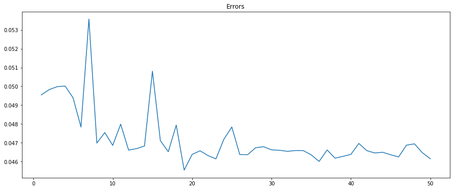

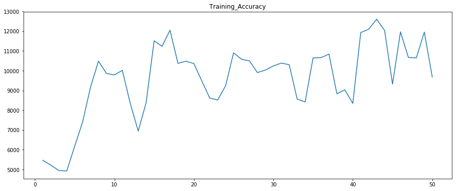

```
Max training accuracy = 12605
Min error = 0.0456
```

```python
plt.figure(figsize=(15,6))
plt.plot(range(1,50+1),stats_10[0])
plt.title('Errors')
plt.show()
plt.figure(figsize=(15,6))
plt.plot(range(1,50+1), stats_10[1])
plt.title('Training_Accuracy')
plt.show()
print "Max training accuracy =", int(np.amax(stats_10[1]))
print ("Min error = %.4f" %(np.amin(stats_10[0])))
```

Here it is not good, the learning rate is too high and accuracy, error fluctuate between each iteration.

**Question 2.2.2 :** initialize all weights to 0. Plot the training accuracy curve. Comment your results

```python
#Your implementation goes here
my_0w_net = NeuralNetwork(784,30,10,50,0.1)
wi=np.zeros((my_0w_net.input, my_0w_net.hidden-1))
wo=np.zeros((my_0w_net.hidden, my_0w_net.output))
my_0w_net.weights_initialisation(wi,wo)

stats_0w = my_0w_net.train(training_data,validation_data, 'sigmoid')
```

```
Iteration:  1/50[==============] -Error: 0.0387166936  -Training_Accuracy:  50.89  -time: 16.96
Iteration:  2/50[==============] -Error: 0.0285556269  -Training_Accuracy:  57.26  -time: 35.80
Iteration:  3/50[==============] -Error: 0.0271611128  -Training_Accuracy:  57.30  -time: 56.67
Iteration:  4/50[==============] -Error: 0.0265862252  -Training_Accuracy:  58.30  -time: 75.01
Iteration:  5/50[==============] -Error: 0.0263757938  -Training_Accuracy:  58.88  -time: 93.25
Iteration:  6/50[==============] -Error: 0.0262644673  -Training_Accuracy:  58.39  -time: 112.75
Iteration:  7/50[==============] -Error: 0.0262341685  -Training_Accuracy:  60.02  -time: 130.41
Iteration:  8/50[==============] -Error: 0.0261849964  -Training_Accuracy:  58.60  -time: 150.38
Iteration:  9/50[==============] -Error: 0.0261756537  -Training_Accuracy:  58.52  -time: 168.13
Iteration: 10/50[==============] -Error: 0.0261200995  -Training_Accuracy:  58.12  -time: 185.13
Iteration: 11/50[==============] -Error: 0.0260717641  -Training_Accuracy:  57.62  -time: 207.77
Iteration: 12/50[==============] -Error: 0.0260864140  -Training_Accuracy:  58.78  -time: 225.35
Iteration: 13/50[==============] -Error: 0.0260719803  -Training_Accuracy:  59.71  -time: 245.18
Iteration: 14/50[==============] -Error: 0.0260673817  -Training_Accuracy:  59.29  -time: 263.80
Iteration: 15/50[==============] -Error: 0.0260338317  -Training_Accuracy:  58.81  -time: 281.66
Iteration: 16/50[==============] -Error: 0.0260241144  -Training_Accuracy:  58.69  -time: 300.53
Iteration: 17/50[==============] -Error: 0.0260097799  -Training_Accuracy:  58.41  -time: 318.99
Iteration: 18/50[==============] -Error: 0.0259956092  -Training_Accuracy:  58.26  -time: 337.74
Iteration: 19/50[==============] -Error: 0.0259992162  -Training_Accuracy:  59.55  -time: 355.51
Iteration: 20/50[==============] -Error: 0.0259873034  -Training_Accuracy:  57.72  -time: 374.36
Iteration: 21/50[==============] -Error: 0.0259832800  -Training_Accuracy:  59.53  -time: 395.59
Iteration: 22/50[==============] -Error: 0.0259847467  -Training_Accuracy:  59.62  -time: 414.85
Iteration: 23/50[==============] -Error: 0.0259877073  -Training_Accuracy:  59.06  -time: 439.60
Iteration: 24/50[==============] -Error: 0.0259562515  -Training_Accuracy:  59.32  -time: 458.56
Iteration: 25/50[==============] -Error: 0.0259461685  -Training_Accuracy:  59.87  -time: 477.28
Iteration: 26/50[==============] -Error: 0.0259647233  -Training_Accuracy:  59.70  -time: 497.55
Iteration: 27/50[==============] -Error: 0.0259321269  -Training_Accuracy:  59.63  -time: 516.51
Iteration: 28/50[==============] -Error: 0.0259557869  -Training_Accuracy:  57.15  -time: 534.27
Iteration: 29/50[==============] -Error: 0.0259114091  -Training_Accuracy:  59.45  -time: 554.40
Iteration: 30/50[==============] -Error: 0.0259285088  -Training_Accuracy:  60.39  -time: 571.26
Iteration: 31/50[==============] -Error: 0.0259123964  -Training_Accuracy:  60.21  -time: 590.46
Iteration: 32/50[==============] -Error: 0.0259063417  -Training_Accuracy:  60.02  -time: 608.36
Iteration: 33/50[==============] -Error: 0.0259216699  -Training_Accuracy:  59.40  -time: 625.85
Iteration: 34/50[==============] -Error: 0.0259060245  -Training_Accuracy:  58.98  -time: 643.48
Iteration: 35/50[==============] -Error: 0.0259024252  -Training_Accuracy:  59.69  -time: 661.01
Iteration: 36/50[==============] -Error: 0.0258769277  -Training_Accuracy:  60.12  -time: 678.07
Iteration: 37/50[==============] -Error: 0.0258820575  -Training_Accuracy:  59.66  -time: 698.36
Iteration: 38/50[==============] -Error: 0.0258754353  -Training_Accuracy:  58.42  -time: 717.83
Iteration: 39/50[==============] -Error: 0.0258964704  -Training_Accuracy:  60.18  -time: 735.98
Iteration: 40/50[==============] -Error: 0.0258719245  -Training_Accuracy:  57.92  -time: 753.24
Iteration: 41/50[==============] -Error: 0.0258719935  -Training_Accuracy:  59.13  -time: 770.80
Iteration: 42/50[==============] -Error: 0.0258743960  -Training_Accuracy:  59.33  -time: 788.75
Iteration: 43/50[==============] -Error: 0.0258927919  -Training_Accuracy:  58.24  -time: 806.08
Iteration: 44/50[==============] -Error: 0.0258638355  -Training_Accuracy:  60.19  -time: 823.54
Iteration: 45/50[==============] -Error: 0.0258847153  -Training_Accuracy:  59.86  -time: 844.68
Iteration: 46/50[==============] -Error: 0.0258735631  -Training_Accuracy:  57.96  -time: 863.44
Iteration: 47/50[==============] -Error: 0.0258853527  -Training_Accuracy:  58.73  -time: 882.04
Iteration: 48/50[==============] -Error: 0.0258629025  -Training_Accuracy:  59.38  -time: 900.15
Iteration: 49/50[==============] -Error: 0.0258790914  -Training_Accuracy:  59.46  -time: 921.50
Iteration: 50/50[==============] -Error: 0.0258531349  -Training_Accuracy:  59.98  -time: 941.25
```

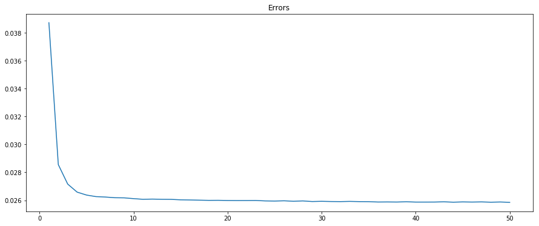

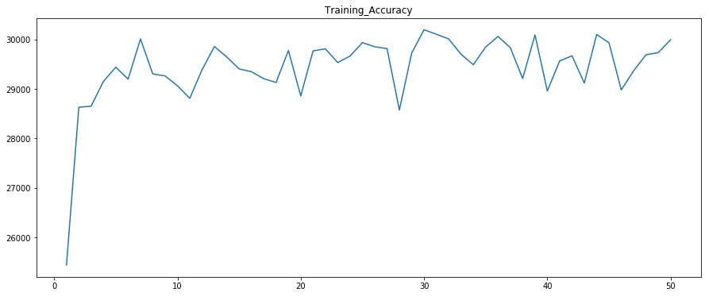

```
Max training accuracy = 30194.0
Min error = 0.0258531349115
```

```python
plt.figure(figsize=(15,6))
plt.plot(range(1,50+1),stats_0w[0])
plt.title('Errors')
plt.show()
plt.figure(figsize=(15,6))
plt.plot(range(1,50+1), stats_0w[1])
plt.title('Training_Accuracy')
plt.show()
print "Max training accuracy =", np.amax(stats_0w[1])
print "Min error =", np.amin(stats_0w[0])
```

**Question 2.2.3 :** Try with a different transfer function (such as tanh). File transfer_functions.py provides you the python implementation of the tanh function and its derivative

```python
#Your implementation goes here
my_tanh_net = NeuralNetwork(784,30,10,50,0.1)
stats_tanh = my_tanh_net.train(training_data,validation_data, 'tanh')
```

```
Iteration:  1/50[==============] -Error: 0.0862289887  -Training_Accuracy:  74.53  -time: 17.49
Iteration:  2/50[==============] -Error: 0.0800864417  -Training_Accuracy:  81.66  -time: 34.34
Iteration:  3/50[==============] -Error: 0.0787512595  -Training_Accuracy:  79.71  -time: 55.46
Iteration:  4/50[==============] -Error: 0.0787862501  -Training_Accuracy:  78.69  -time: 74.47
Iteration:  5/50[==============] -Error: 0.0786211359  -Training_Accuracy:  84.94  -time: 91.70
Iteration:  6/50[==============] -Error: 0.0782057185  -Training_Accuracy:  83.30  -time: 109.32
Iteration:  7/50[==============] -Error: 0.0777705962  -Training_Accuracy:  88.66  -time: 126.13
Iteration:  8/50[==============] -Error: 0.0776815889  -Training_Accuracy:  73.58  -time: 142.25
Iteration:  9/50[==============] -Error: 0.0780670813  -Training_Accuracy:  68.87  -time: 162.37
Iteration: 10/50[==============] -Error: 0.0775793358  -Training_Accuracy:  85.88  -time: 185.07
Iteration: 11/50[==============] -Error: 0.0781304227  -Training_Accuracy:  87.87  -time: 203.37
Iteration: 12/50[==============] -Error: 0.0778902656  -Training_Accuracy:  79.99  -time: 219.88
Iteration: 13/50[==============] -Error: 0.0770361822  -Training_Accuracy:  76.17  -time: 236.28
Iteration: 14/50[==============] -Error: 0.0774276334  -Training_Accuracy:  87.31  -time: 252.55
Iteration: 15/50[==============] -Error: 0.0770478233  -Training_Accuracy:  87.86  -time: 270.32
Iteration: 16/50[==============] -Error: 0.0771772759  -Training_Accuracy:  87.23  -time: 286.18
Iteration: 17/50[==============] -Error: 0.0774569339  -Training_Accuracy:  88.76  -time: 301.50
Iteration: 18/50[==============] -Error: 0.0775633035  -Training_Accuracy:  62.61  -time: 316.73
Iteration: 19/50[==============] -Error: 0.0772527625  -Training_Accuracy:  86.24  -time: 332.12
Iteration: 20/50[==============] -Error: 0.0768513922  -Training_Accuracy:  77.77  -time: 349.72
Iteration: 21/50[==============] -Error: 0.0764827929  -Training_Accuracy:  86.23  -time: 366.88
Iteration: 22/50[==============] -Error: 0.0768625611  -Training_Accuracy:  89.83  -time: 383.06
Iteration: 23/50[==============] -Error: 0.0766393873  -Training_Accuracy:  88.56  -time: 399.64
Iteration: 24/50[==============] -Error: 0.0761007602  -Training_Accuracy:  86.07  -time: 416.17
Iteration: 25/50[==============] -Error: 0.0763246392  -Training_Accuracy:  87.43  -time: 432.38
Iteration: 26/50[==============] -Error: 0.0759660212  -Training_Accuracy:  90.10  -time: 448.85
Iteration: 27/50[==============] -Error: 0.0759809332  -Training_Accuracy:  83.94  -time: 465.33
Iteration: 28/50[==============] -Error: 0.0752855669  -Training_Accuracy:  73.50  -time: 481.96
Iteration: 29/50[==============] -Error: 0.0749878671  -Training_Accuracy:  88.63  -time: 497.44
Iteration: 30/50[==============] -Error: 0.0754015151  -Training_Accuracy:  88.98  -time: 514.62
Iteration: 31/50[==============] -Error: 0.0752981600  -Training_Accuracy:  86.95  -time: 531.19
Iteration: 32/50[==============] -Error: 0.0753273766  -Training_Accuracy:  86.94  -time: 548.30
Iteration: 33/50[==============] -Error: 0.0753963003  -Training_Accuracy:  84.20  -time: 564.81
Iteration: 34/50[==============] -Error: 0.0759371274  -Training_Accuracy:  87.27  -time: 581.54
Iteration: 35/50[==============] -Error: 0.0755454908  -Training_Accuracy:  77.53  -time: 597.44
Iteration: 36/50[==============] -Error: 0.0748296325  -Training_Accuracy:  87.77  -time: 613.22
Iteration: 37/50[==============] -Error: 0.0752435876  -Training_Accuracy:  88.58  -time: 630.55
Iteration: 38/50[==============] -Error: 0.0754124507  -Training_Accuracy:  75.95  -time: 648.26
Iteration: 39/50[==============] -Error: 0.0746318147  -Training_Accuracy:  87.68  -time: 663.98
Iteration: 40/50[==============] -Error: 0.0750142388  -Training_Accuracy:  84.33  -time: 680.66
Iteration: 41/50[==============] -Error: 0.0749942572  -Training_Accuracy:  88.57  -time: 696.90
Iteration: 42/50[==============] -Error: 0.0752334461  -Training_Accuracy:  89.14  -time: 713.21
Iteration: 43/50[==============] -Error: 0.0747454047  -Training_Accuracy:  89.56  -time: 729.69
Iteration: 44/50[==============] -Error: 0.0749042978  -Training_Accuracy:  75.87  -time: 746.13
Iteration: 45/50[==============] -Error: 0.0751732057  -Training_Accuracy:  82.99  -time: 765.32
Iteration: 46/50[==============] -Error: 0.0753717425  -Training_Accuracy:  87.54  -time: 783.74
Iteration: 47/50[==============] -Error: 0.0753650894  -Training_Accuracy:  88.82  -time: 799.93
Iteration: 48/50[==============] -Error: 0.0748831025  -Training_Accuracy:  85.21  -time: 816.68
Iteration: 49/50[==============] -Error: 0.0751205438  -Training_Accuracy:  90.16  -time: 833.78
Iteration: 50/50[==============] -Error: 0.0747891378  -Training_Accuracy:  89.91  -time: 850.33
```

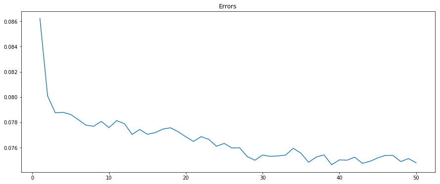

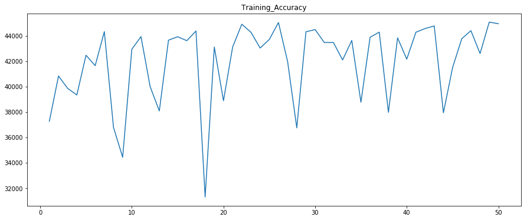

```
Max training accuracy = 45081.0
Min error = 0.0746318146562
```

```python
plt.figure(figsize=(15,6))
plt.plot(range(1,50+1),stats_tanh[0])
plt.title('Errors')
plt.show()
plt.figure(figsize=(15,6))
plt.plot(range(1,50+1), stats_tanh[1])
plt.title('Training_Accuracy')
plt.show()
print "Max training accuracy =", np.amax(stats_tanh[1])
print "Min error =", np.amin(stats_tanh[0])
```

Use tanh as as the transfert function is not a good idea.

**Question 2.2.4 :** Add more neurons in the hidden layer (try with 100, 200, 300). Plot the curve representing the validation accuracy versus the number of neurons in the hidden layer. (Choose and justify other hyper-parameters)

```python
#Your implementation goes here
my_100h_net = NeuralNetwork(784,100,10,30,0.1)
my_200h_net = NeuralNetwork(784,200,10,30,0.1)
my_300h_net = NeuralNetwork(784,300,10,30,0.1)
stats_100h = my_100h_net.train(training_data,validation_data, 'sigmoid')
stats_200h = my_200h_net.train(training_data,validation_data, 'sigmoid')
stats_300h = my_300h_net.train(training_data,validation_data, 'sigmoid')
```

```
Iteration:  1/30[==============] -Error: 0.0095256485  -Training_Accuracy:  89.38  -time: 28.89
Iteration:  2/30[==============] -Error: 0.0060189410  -Training_Accuracy:  91.90  -time: 58.92
Iteration:  3/30[==============] -Error: 0.0048951174  -Training_Accuracy:  93.24  -time: 89.12
Iteration:  4/30[==============] -Error: 0.0042135834  -Training_Accuracy:  94.12  -time: 121.80
Iteration:  5/30[==============] -Error: 0.0037172679  -Training_Accuracy:  94.64  -time: 155.82
Iteration:  6/30[==============] -Error: 0.0033343326  -Training_Accuracy:  95.13  -time: 185.27
Iteration:  7/30[==============] -Error: 0.0030536708  -Training_Accuracy:  95.52  -time: 217.13
Iteration:  8/30[==============] -Error: 0.0028236193  -Training_Accuracy:  95.93  -time: 248.75
Iteration:  9/30[==============] -Error: 0.0026456464  -Training_Accuracy:  96.21  -time: 277.67
Iteration: 10/30[==============] -Error: 0.0024852671  -Training_Accuracy:  96.41  -time: 307.44
Iteration: 11/30[==============] -Error: 0.0023414161  -Training_Accuracy:  96.62  -time: 336.33
Iteration: 12/30[==============] -Error: 0.0022125405  -Training_Accuracy:  96.83  -time: 370.20
Iteration: 13/30[==============] -Error: 0.0021057327  -Training_Accuracy:  96.95  -time: 406.42
Iteration: 14/30[==============] -Error: 0.0020114395  -Training_Accuracy:  97.10  -time: 435.66
Iteration: 15/30[==============] -Error: 0.0019129417  -Training_Accuracy:  97.21  -time: 465.84
Iteration: 16/30[==============] -Error: 0.0018298101  -Training_Accuracy:  97.27  -time: 498.43
Iteration: 17/30[==============] -Error: 0.0017628283  -Training_Accuracy:  97.39  -time: 534.07
Iteration: 18/30[==============] -Error: 0.0016952987  -Training_Accuracy:  97.51  -time: 565.72
Iteration: 19/30[==============] -Error: 0.0016430457  -Training_Accuracy:  97.60  -time: 597.63
Iteration: 20/30[==============] -Error: 0.0015935528  -Training_Accuracy:  97.65  -time: 629.80
Iteration: 21/30[==============] -Error: 0.0015377333  -Training_Accuracy:  97.73  -time: 662.78
Iteration: 22/30[==============] -Error: 0.0014879025  -Training_Accuracy:  97.79  -time: 692.29
Iteration: 23/30[==============] -Error: 0.0014545666  -Training_Accuracy:  97.85  -time: 724.71
Iteration: 24/30[==============] -Error: 0.0014038237  -Training_Accuracy:  97.94  -time: 756.24
Iteration: 25/30[==============] -Error: 0.0013638506  -Training_Accuracy:  97.99  -time: 786.82
Iteration: 26/30[==============] -Error: 0.0013335231  -Training_Accuracy:  98.01  -time: 817.32
Iteration: 27/30[==============] -Error: 0.0013016742  -Training_Accuracy:  98.06  -time: 848.95
Iteration: 28/30[==============] -Error: 0.0012689246  -Training_Accuracy:  98.06  -time: 880.96
```

[output not shown]

**Question 2.2.5 :** Add one additionnal hidden layers and train your network, discuss your results with different setting.

```python
#Your implementation goes here
```